# Modulvorstellung KI (Wahlfach Liste 1)

IFM 5.14 Künstliche Intelligenz, W19

Carsten Gips, FH Bielefeld

## Was ist *Künstliche Intelligenz*?

[figure not shown]

Quelle: [wikipedia.de](https://en.wikipedia.org/wiki/File:DataTNG.jpg)

[figure not shown]

Quelle: [wikipedia.de](https://en.wikipedia.org/wiki/File:R2-D2_Droid.png)

- Was ist *Intelligenz*? Was ist *künstliche Intelligenz*?
- Wie kann man intelligentes Verhalten erreichen?
- Wie kann man lernfähige Systeme programmieren?
- Was braucht man alles, um intelligente Systeme zu bauen?

=> Welche **Gebiete der KI** gibt es? Welche **wichtigen Algorithmen** gibt es? Wie **funktionieren** diese?

## Überblick über wichtige Methoden der KI

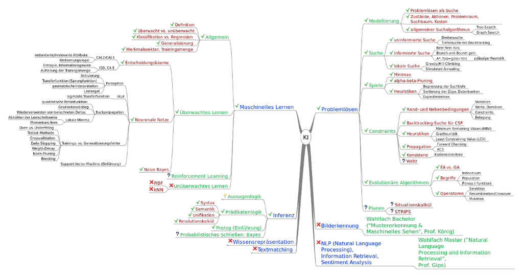

**Veranstaltungsform**:

2 SWS Vorlesung (=> Klausur), 2 SWS Praktikum (=> Testat)

=> **Programmiersprache (meist) frei wählbar!**

Wir werden in der Vorlesung die wichtigsten Gebiete der (modernen) KI betrachten und jeweils grundlegende Methoden besprechen und uns die Wirkungsweise an Beispielen anschauen.

*Anmerkung*: Die in der Mindmap mit einem roten Kreuz markierten Themen sind Bestandteil anderer Veranstaltungen (Bilderkennung: Wahlfach Bachelor “Mustererkennung & Maschinelles Sehen”, Prof. König; Machine Learning mit Schwerpunkt auf NLP (Natural Language Processing), Information Retrieval und Sentiment Analysis: Wahlfach Master “Natural Language Processing and Information Retrieval”, Prof. Gips) und werden deshalb in diesem Modul explizit ausgeklammert. Die mit Fragezeichen markierten Themen können je nach verfügbarer Zeit und Interesse der Teilnehmer zusätzlich mit aufgenommen werden.

Im Praktikum wird es dazu kleinere Aufgaben geben, die Sie wie gewohnt zuhause bearbeiten und deren Lösung Sie im Praktikum vorstellen.

Voraussichtlich wird es 10 Übungsblätter geben, wobei für das Erreichen des Testats voraussichtlich mindestens 5 Blätter erfolgreich bearbeitet werden müssen. “Erfolgreich bearbeitet” bedeutet, dass jeweils mind. 50% der Aufgaben des Blattes bearbeitet wurden und im Praktikum vorgestellt wurden.

Ziel ist dabei vor allem, dass Sie untereinander ins Gespräch kommen und spannende alternative Lösungen entwickeln und vorstellen, sich gegenseitig weiterhelfen und Spaß an der KI haben :-)

Die Credits für die Veranstaltung erhalten Sie durch das Erlangen des Testats für die erfolgreiche Teilnahme am Praktikum. Die Note für die Veranstaltung ergibt sich aus der Klausurnote.

## Sie werden einen Einblick in folgende Gebiete bekommen (u.a.)

### Suchen und Planen

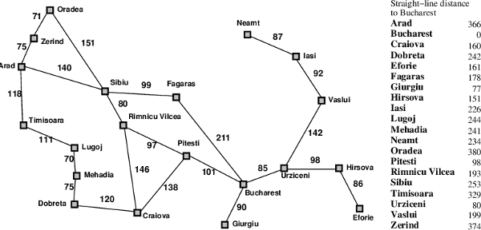

Quelle: (Russell und Norvig 2014)

Finde *einen* Weg von Arad nach Bucharest. Finde den *schnellsten* Weg von Arad nach Bucharest. Finde den *billigsten* Weg von Arad nach Bucharest.

### Evolution: Genetische Algorithmen

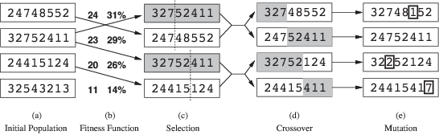

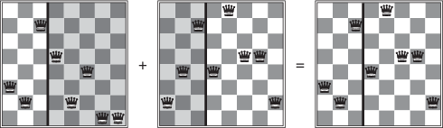

Quelle: (Russell und Norvig 2014)

Wie formuliert man ein komplexes Problem (beispielsweise das N-Queens-Problem) so, dass man es mit Hilfe von Mechanismen der Evolution lösen lassen kann? Welche Operatoren gibt es dabei? Wie formuliert man eine Zielfunktion?

### Spiele und Constraintprobleme

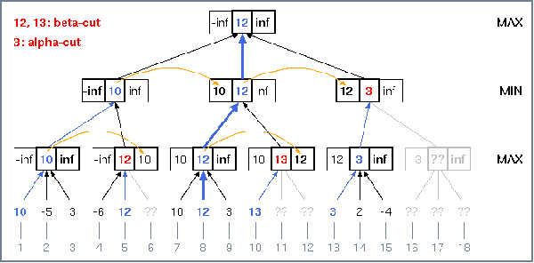

Quelle: [Antonsusi (gemeinfrei, wikipedia.de)](https://de.wikipedia.org/wiki/Datei:Alpha_beta.svg)

Was steckt hinter den “KI”s in Computerspielen? Wie funktionieren diese? Wie baue ich den (perfekt) spielenden Computer-Gegner?

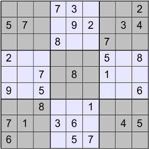

Sudoku ist ein Spiel, bei dem die möglichen Werte für die Felder durch bestimmte Bedingungen eingeschränkt werden. Wie kann man solche Probleme lösen?

### Maschinelles Lernen

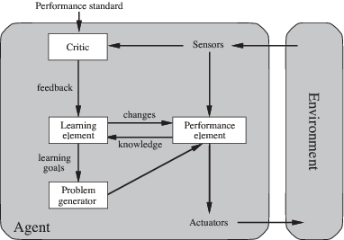

Quelle: (Russell und Norvig 2014)

Was bedeutet “Lernen”? Wie kann eine Maschine lernen? Welche Formen des Lernens gibt es? Mein Lieblingsgebiet in der KI :-)

### Von der biologischen Nervenzelle …

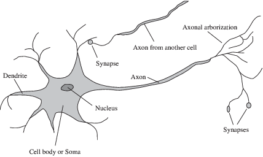

Quelle: (Russell und Norvig 2014)

### … zum Künstlichen Neuronalen Netz und Backpropagation

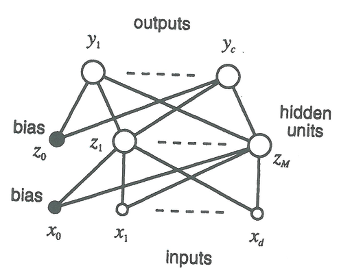

Quelle: (Bishop 2010, 117)

Wie funktioniert eine Nervenzelle? Wie kann man ein einfaches Modell einer biologischen Nervenzelle implementieren? Was passiert, wenn man mehrere solcher Gebilde zusammen benutzt? Wie kann man damit lernen?

### Gebiete der KI, mal anderes betrachtet :-)

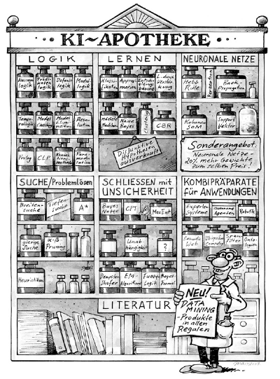

Quelle: (Ertel 2016, 5)

Tja, *so* kann die Gebiete der KI auch darstellen :-) … Wir werden in fast alle Fächer des “Apothekenschranks” hereinschnuppern und schauen, wie es funktioniert und wozu es gut ist. Am Ende haben Sie dann einen Baukasten an Methoden, die man zur Lösung unterschiedlichster Probleme nutzen kann.

## Bibliographie

Bishop, C. M. 2010. *Neural Networks for Pattern Recognition*. Oxford University Press. ISBN: 978-0-1985-3864-6.

Ertel, W. 2016. *Grundkurs Künstliche Intelligenz*. 4. Auflage. Springer Vieweg. DOI: 10.1007/978-3-658-13549-2.

Russell, S.; und P. Norvig. 2014. *Artificial Intelligence: A Modern Approach*. 3rd revised edition. Pearson. ISBN: 978-1-292-02420-2. URL: http://aima.cs.berkeley.edu (zugegriffen 17.07.2018).